# Reproducible Research: Peer Assessment 1

## Imputing missing values

```r
missing_records <- sum(is.na(infile)*1)
```

1. There are 2304 rows that have NA steps in the data.
2. Interval is more indicative of step count than date, so we will impute missing values by using the interval mean

```r
infile_na <- infile[is.na(infile$steps) == TRUE,]
uniq_na_combo <- length(unique(infile_na$interval))
infile_uniq_no_na <- infile_no_na %>% group_by(interval) %>% summarize(steps_imputed = mean(steps))
infile_na <- merge(infile_na, infile_uniq_no_na, by = "interval")
```

3. Fill in original dataset with imputed steps for NAs

```r
infile_imputed <- merge(infile, infile_uniq_no_na, by = "interval")
infile_imputed[is.na(infile_imputed$steps)==TRUE,]$steps <- infile_imputed[is.na(infile_imputed$steps)==TRUE,]$steps_imputed
infile_imputed <- infile_imputed[1:3]
```

4. Create histogram and calculate mean and median

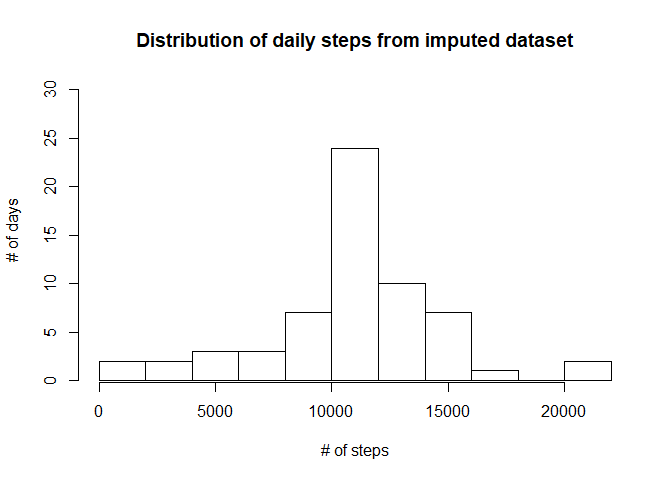

```r
infile_day_level <- infile_imputed %>% group_by(date) %>% summarize(steps = sum(steps))

hist(infile_day_level$steps, main="Distribution of daily steps from imputed dataset",
        xlab = "# of steps",
        ylab = "# of days",
        ylim = c(1,30),
        breaks = 10,
        freq=TRUE
        )
```

```r
mean_step_imputed <- as.integer(summary(infile_day_level$steps)[4])
median_step_imputed <- as.integer(summary(infile_day_level$steps)[3])
```

The mean from the imputed dataset is 10766; the median from the imputed dataset is 10766. The missing values do not have significant impact on the results as they do not differ much from the orignal dataset with NAs.

## Are there differences in activity patterns between weekdays and weekends?

1. Add variable for weekday/weekend qualifier

```r
wkdy <- c("Monday", "Tuesday", "Wednesday", "Thursday", "Friday")
infile_imputed$day <- factor((weekdays(infile_imputed$date) %in% wkdy),
         levels=c(FALSE, TRUE), labels=c('weekend', 'weekday'))
```

2. Average step numbers by interval for Weekend vs weekday

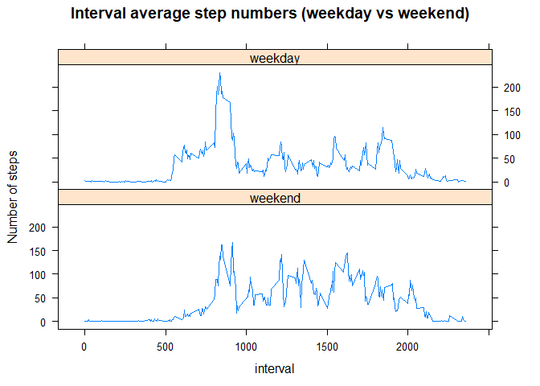

```r
infile_int_time_series_imputed <- infile_imputed %>% group_by(interval,day) %>% summarize(steps = mean(steps))

library(lattice)
xyplot(steps ~ interval | day,
       data = infile_int_time_series_imputed,
       type = "l",
       layout = c(1,2),
       ylab = "Number of steps",
       main = "Interval average step numbers (weekday vs weekend)")
```

There tends to be more steps distributed more evenly across the day on the weekends than weekdays. The activity during weekdays tend to happen earlier in the day.